# Experiments

Thanh Long Vu (Oliver)

2026-08-31

## Experiment Framing

The experiments are grouped into three categories:

- **Favourable / validation cases**
  - Experiment 1: Standard SIR model
  - Experiment 2: Independent birth-death process
- **Partial success / trade-off case**
  - Experiment 3: Weakly coupled two-species birth-death model
- **Limitation / edge cases**
  - Limitation Case 1: Time-dependent birth-death process
  - Edge Case 2: Catalytic time-scale separation

The goal is not to show that the current Jump-Tau-Flow prototype always works. Instead, the goal is to understand:

1. when it reproduces the behaviour of exact SSA well,
2. when it gives useful but incomplete approximations, and
3. when coupling between the Jump, Tau, and Flow regimes begins to fail.

Because all models considered here are stochastic, accuracy is assessed primarily using **ensemble-level behaviour over repeated simulations**, rather than by comparing individual stochastic trajectories.

For all distributional comparisons, Exact SSA and JSF + Tau use **exactly the same histogram bin boundaries and bin widths**.

For time-dependent comparisons, repeated simulations are evaluated on a common time grid. The plots show:

- the ensemble mean trajectory, and
- the 5th to 95th percentile simulation envelope.

This gives a more meaningful comparison of the stochastic processes than comparing two arbitrary individual realizations.

## Helper Functions

```r
# Interpolate a simulated trajectory onto a common plotting grid.
#
# This is used only for ensemble summaries over time.
path_on_grid <- function(out, species, grid) {
  idx <- findInterval(grid, out$time)
  idx[idx < 1] <- 1
  idx[idx > length(out[[species]])] <- length(out[[species]])

  out[[species]][idx]
}

# Summarise an ensemble of trajectories.
#
# Rows = simulation replicates
# Columns = time points
summarise_paths <- function(path_matrix) {
  list(
    mean = colMeans(path_matrix),
    lower = apply(
      path_matrix,
      2,
      quantile,
      probs = 0.05,
      na.rm = TRUE
    ),
    upper = apply(
      path_matrix,
      2,
      quantile,
      probs = 0.95,
      na.rm = TRUE
    )
  )
}


plot_ensemble_comparison <- function(
    grid,
    exact_paths,
    hybrid_paths,
    ylab,
    main
) {

  exact_summary <- summarise_paths(exact_paths)
  hybrid_summary <- summarise_paths(hybrid_paths)

  ylim <- range(
    exact_summary$lower,
    exact_summary$upper,
    hybrid_summary$lower,
    hybrid_summary$upper,
    finite = TRUE
  )

  plot(
    grid,
    exact_summary$mean,
    type = "n",
    ylim = ylim,
    xlab = "Time",
    ylab = ylab,
    main = main
  )

  polygon(
    c(grid, rev(grid)),
    c(exact_summary$lower, rev(exact_summary$upper)),
    col = rgb(0, 0, 0, 0.15),
    border = NA
  )

  polygon(
    c(grid, rev(grid)),
    c(hybrid_summary$lower, rev(hybrid_summary$upper)),
    col = rgb(1, 0, 0, 0.15),
    border = NA
  )

  lines(
    grid,
    exact_summary$mean,
    lwd = 2
  )

  lines(
    grid,
    hybrid_summary$mean,
    lwd = 2,
    lty = 2,
    col = "red"
  )

  legend(
    "topright",
    legend = c(
      "Exact SSA mean",
      "JSF + Tau mean"
    ),
    lty = c(1, 2),
    lwd = 2,
    col = c("black", "red"),
    bty = "n"
  )
}

# Construct one set of equally spaced histogram breaks
# from the combined Exact SSA and JSF + Tau samples.
#
# Both histograms therefore have exactly the same bin width
# and exactly the same bin boundaries.
common_hist_breaks <- function(
    exact_values,
    hybrid_values,
    n_bins = 20
) {

  all_values <- c(exact_values, hybrid_values)

  lower <- min(all_values, na.rm = TRUE)
  upper <- max(all_values, na.rm = TRUE)

  if (lower == upper) {
    lower <- lower - 0.5
    upper <- upper + 0.5
  }

  seq(
    from = lower,
    to = upper,
    length.out = n_bins + 1
  )
}
```

# Experiment 1: Standard SIR Model

## Goal

This experiment tests whether the current Jump-Tau-Flow prototype behaves reasonably on a standard SIR epidemic model with moderate infection and recovery rates.

This is intended as a favourable validation case because the system is coupled, but the propensities should not change too violently over a small time step.

The hybrid method is compared against the exact SSA / Gillespie solver using repeated simulations.

## Model

The SIR model has three compartments:

$$X(t) = (S(t), I(t), R(t)).$$

The reactions are:

$$S + I \rightarrow 2I$$

and

$$I \rightarrow R.$$

The corresponding propensities are:

$$a_1(X)
=
\beta \frac{SI}{N},$$

and

$$a_2(X)
=
\gamma I.$$

## Rates and Simulation Parameters

The numerical rate values used in this experiment are:

| Quantity | Value | Meaning |
| --- | --- | --- |
| $\beta$ | 0.5 | Infection-rate parameter |
| $\gamma$ | 0.1 | Recovery-rate parameter |
| $N$ | 1000 | Total population |
| $S(0)$ | 990 | Initial susceptible population |
| $I(0)$ | 10 | Initial infected population |
| $R(0)$ | 0 | Initial recovered population |
| $t_{\max}$ | 20 | Simulation horizon |
| Exact SSA `dt` | 0.1 | Output / integration setting |
| Hybrid `dt` | 0.1 | Hybrid time-step setting |
| Hybrid switching threshold | 10 | Jump / Tau / Flow switching threshold |
| Hybrid Tau threshold | 200 | Tau / Flow threshold |

Therefore, for example, at any state $(S,I,R)$,

$$a_{\text{infection}}
=
0.5\frac{SI}{1000},$$

and

$$a_{\text{recovery}}
=
0.1I.$$

## Setup

```r
rates_sir <- reticulate::py_eval(
  "lambda x, t: [0.5 * x[0] * x[1] / 1000, 0.1 * x[1]]"
)

reactant_sir <- matrix(c(
  1, 1, 0,   # infection: S + I -> 2I
  0, 1, 0    # recovery:  I -> R
), ncol = 3, byrow = TRUE)

product_sir <- matrix(c(
  0, 2, 0,   # infection
  0, 0, 1    # recovery
), ncol = 3, byrow = TRUE)
```

## Regime Usage Check

The following run is used only to inspect which numerical regimes are activated by the hybrid implementation.

It is an implementation diagnostic and is **not** used as evidence of statistical agreement with Exact SSA.

```r
sir_log <- capture.output(
  out_sir_debug <- jsf_simulate(
    x0 = c(S = 990, I = 10, R = 0),
    rates = rates_sir,
    reactant = reactant_sir,
    product = product_sir,
    do_disc = c(0, 1, 0),
    t_max = 20,
    dt = 0.1,
    switching_threshold = c(10, 10, 10),
    tau_threshold = c(200, 200, 200),
    species_names = c("S", "I", "R"),
    method = "tau-operator-splitting",
    tau_debug = TRUE,
    tau_debug_every = 10,
    tau_debug_max = 50
  )
)

cat(sir_log, sep = "\n")
```

```
## t=0.000, X=[990.0, 10.0, 0.0], compartmentMode=['flow', 'jump', 'jump'], reactionMode=['jump', 'jump']
## t=1.000, X=[987.0, 13.0, 0.0], compartmentMode=['flow', 'tau', 'jump'], reactionMode=['tau', 'jump']
## t=2.000, X=[973.0, 26.0, 1.0], compartmentMode=['flow', 'tau', 'jump'], reactionMode=['tau', 'jump']
## t=3.000, X=[963.0, 33.0, 4.0], compartmentMode=['flow', 'tau', 'jump'], reactionMode=['tau', 'jump']
## t=4.000, X=[943.0, 52.0, 5.0], compartmentMode=['flow', 'tau', 'jump'], reactionMode=['tau', 'jump']
## t=5.000, X=[909.0, 80.0, 11.0], compartmentMode=['flow', 'tau', 'tau'], reactionMode=['tau', 'tau']
## t=6.000, X=[864.0, 121.0, 15.0], compartmentMode=['flow', 'tau', 'tau'], reactionMode=['tau', 'tau']
## t=7.000, X=[809.0, 157.0, 34.0], compartmentMode=['flow', 'tau', 'tau'], reactionMode=['tau', 'tau']
## t=8.000, X=[731.481, 218.519, 50.0], compartmentMode=['flow', 'flow', 'tau'], reactionMode=['flow', 'tau']
## t=9.000, X=[646.595, 279.405, 74.0], compartmentMode=['flow', 'flow', 'tau'], reactionMode=['flow', 'tau']
## t=10.000, X=[553.283, 349.717, 97.0], compartmentMode=['flow', 'flow', 'tau'], reactionMode=['flow', 'tau']
## t=11.000, X=[457.45, 411.55, 131.0], compartmentMode=['flow', 'flow', 'tau'], reactionMode=['flow', 'tau']
## t=12.000, X=[366.848, 459.152, 174.0], compartmentMode=['flow', 'flow', 'tau'], reactionMode=['flow', 'tau']
## t=13.000, X=[287.582, 501.461, 210.956], compartmentMode=['flow', 'flow', 'flow'], reactionMode=['flow', 'flow']
## t=14.000, X=[222.194, 515.918, 261.888], compartmentMode=['flow', 'flow', 'flow'], reactionMode=['flow', 'flow']
## t=15.000, X=[171.016, 515.416, 313.568], compartmentMode=['flow', 'flow', 'flow'], reactionMode=['flow', 'flow']
## t=16.000, X=[132.032, 503.322, 364.646], compartmentMode=['flow', 'flow', 'flow'], reactionMode=['flow', 'flow']
## t=17.000, X=[102.776, 483.102, 414.122], compartmentMode=['flow', 'flow', 'flow'], reactionMode=['flow', 'flow']
## t=18.000, X=[80.941, 457.736, 461.323], compartmentMode=['flow', 'flow', 'flow'], reactionMode=['flow', 'flow']
## t=19.000, X=[64.625, 429.532, 505.843], compartmentMode=['flow', 'flow', 'flow'], reactionMode=['flow', 'flow']
```

```r
sir_regime_usage <- data.frame(
  mode = c(
    "Tau appears",
    "Jump appears",
    "Flow appears"
  ),
  debug_steps = c(
    sum(grepl("reactionMode=.*tau", sir_log)),
    sum(grepl("reactionMode=.*jump", sir_log)),
    sum(grepl("reactionMode=.*flow", sir_log))
  )
)

sir_regime_usage
```

```
##           mode debug_steps
## 1  Tau appears          12
## 2 Jump appears           5
## 3 Flow appears          12
```

## Ensemble Comparison

In addition to final-state summary statistics, infected-population trajectories are evaluated on the same time grid so that the ensemble mean and stochastic spread can be compared over time.

```r
n_rep <- 500

sir_grid <- seq(
  from = 0,
  to = 20,
  by = 0.1
)

final_R_exact <- numeric(n_rep)
final_R_hybrid <- numeric(n_rep)

peak_I_exact <- numeric(n_rep)
peak_I_hybrid <- numeric(n_rep)

time_exact <- numeric(n_rep)
time_hybrid <- numeric(n_rep)

I_paths_exact <- matrix(
  NA_real_,
  nrow = n_rep,
  ncol = length(sir_grid)
)

I_paths_hybrid <- matrix(
  NA_real_,
  nrow = n_rep,
  ncol = length(sir_grid)
)

for (r in seq_len(n_rep)) {

  t_exact <- system.time({
    exact_r <- jsf_simulate(
      x0 = c(S = 990, I = 10, R = 0),
      rates = rates_sir,
      reactant = reactant_sir,
      product = product_sir,
      do_disc = c(1, 1, 1),
      t_max = 20,
      dt = 0.1,
      switching_threshold = c(1e9, 1e9, 1e9),
      species_names = c("S", "I", "R"),
      method = "exact"
    )
  })

  t_hybrid <- system.time({
    hybrid_r <- jsf_simulate(
      x0 = c(S = 990, I = 10, R = 0),
      rates = rates_sir,
      reactant = reactant_sir,
      product = product_sir,
      do_disc = c(0, 1, 0),
      t_max = 20,
      dt = 0.1,
      switching_threshold = c(10, 10, 10),
      tau_threshold = c(200, 200, 200),
      species_names = c("S", "I", "R"),
      method = "tau-operator-splitting"
    )
  })

  final_R_exact[r] <- tail(exact_r$R, 1)
  final_R_hybrid[r] <- tail(hybrid_r$R, 1)

  peak_I_exact[r] <- max(exact_r$I)
  peak_I_hybrid[r] <- max(hybrid_r$I)

  time_exact[r] <- t_exact["elapsed"]
  time_hybrid[r] <- t_hybrid["elapsed"]

  I_paths_exact[r, ] <- path_on_grid(
    exact_r,
    "I",
    sir_grid
  )

  I_paths_hybrid[r, ] <- path_on_grid(
    hybrid_r,
    "I",
    sir_grid
  )
}
```

## Ensemble Infected-Population Trajectory

The solid and dashed lines show the ensemble means.

The shaded regions show the 5th to 95th percentile simulation envelopes.

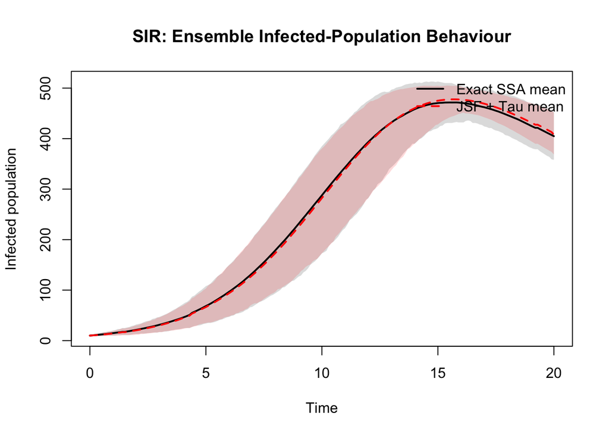

```r
plot_ensemble_comparison(
  grid = sir_grid,
  exact_paths = I_paths_exact,
  hybrid_paths = I_paths_hybrid,
  ylab = "Infected population",
  main = "SIR: Ensemble Infected-Population Behaviour"
)
```

## Summary Metrics

```r
sir_summary <- data.frame(
  method = c(
    "Exact SSA",
    "JSF + Tau"
  ),
  mean_final_R = c(
    mean(final_R_exact),
    mean(final_R_hybrid)
  ),
  sd_final_R = c(
    sd(final_R_exact),
    sd(final_R_hybrid)
  ),
  mean_peak_I = c(
    mean(peak_I_exact),
    mean(peak_I_hybrid)
  ),
  sd_peak_I = c(
    sd(peak_I_exact),
    sd(peak_I_hybrid)
  ),
  mean_runtime_seconds = c(
    mean(time_exact),
    mean(time_hybrid)
  )
)

sir_summary
```

```
##      method mean_final_R sd_final_R mean_peak_I sd_peak_I mean_runtime_seconds
## 1 Exact SSA      518.094   46.57075    486.5220  20.74720             0.092072
## 2 JSF + Tau      518.174   42.93865    484.9976  15.17871             0.001376
```

## Error Against Exact SSA

```r
sir_error <- data.frame(
  metric = c(
    "Mean final R error",
    "Relative mean final R error",
    "Mean peak I error",
    "Relative mean peak I error",
    "Runtime ratio: hybrid / exact",
    "Speed-up: exact / hybrid"
  ),
  value = c(
    mean(final_R_hybrid) -
      mean(final_R_exact),

    (
      mean(final_R_hybrid) -
        mean(final_R_exact)
    ) /
      mean(final_R_exact),

    mean(peak_I_hybrid) -
      mean(peak_I_exact),

    (
      mean(peak_I_hybrid) -
        mean(peak_I_exact)
    ) /
      mean(peak_I_exact),

    mean(time_hybrid) /
      mean(time_exact),

    mean(time_exact) /
      mean(time_hybrid)
  )
)

sir_error
```

```
##                          metric         value
## 1            Mean final R error  0.0799581010
## 2   Relative mean final R error  0.0001543313
## 3             Mean peak I error -1.5244147804
## 4    Relative mean peak I error -0.0031332905
## 5 Runtime ratio: hybrid / exact  0.0149448258
## 6      Speed-up: exact / hybrid 66.9127906977
```

## Final-Size Distribution

The same histogram breaks are calculated once from the combined Exact SSA and hybrid samples.

Therefore, both histograms have identical bin boundaries and bin widths.

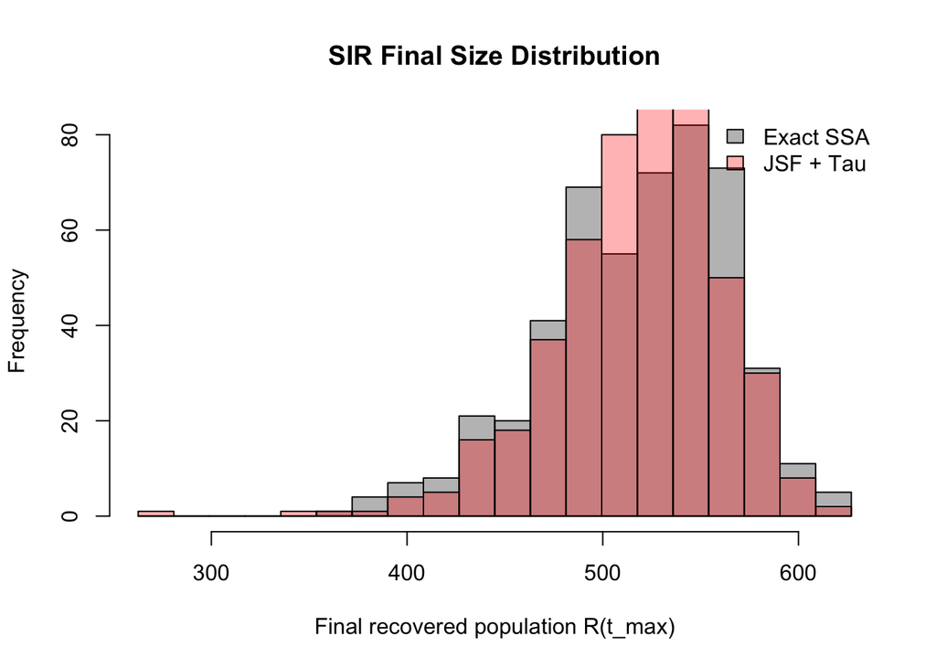

```r
sir_breaks <- common_hist_breaks(
  final_R_exact,
  final_R_hybrid,
  n_bins = 20
)

hist(
  final_R_exact,
  breaks = sir_breaks,
  xlim = range(sir_breaks),
  xlab = "Final recovered population R(t_max)",
  main = "SIR Final Size Distribution",
  col = rgb(0, 0, 0, 0.3)
)

hist(
  final_R_hybrid,
  breaks = sir_breaks,
  col = rgb(1, 0, 0, 0.3),
  add = TRUE
)

legend(
  "topright",
  legend = c(
    "Exact SSA",
    "JSF + Tau"
  ),
  fill = c(
    rgb(0, 0, 0, 0.3),
    rgb(1, 0, 0, 0.3)
  ),
  bty = "n"
)
```

## Interpretation

This experiment is a favourable validation case for the current Jump-Tau-Flow prototype.

**What works well**

- The hybrid method captures the main ensemble-level behaviour of Exact SSA.
- The ensemble infected-population curves can be compared across the full simulation horizon rather than through two arbitrary individual realizations.
- The mean final recovered population is close to Exact SSA.
- The mean peak infected population is also close to Exact SSA.
- The final-size distributions show substantial overlap.
- The method gives a large runtime improvement compared with Exact SSA.
- This suggests that the coupling behaves reasonably for a moderate nonlinear system when the time step is small.

**What should be interpreted carefully**

- Individual stochastic epidemic trajectories naturally vary between simulations.
- Agreement should therefore be judged primarily through repeated-simulation statistics, ensemble trajectories, and distributions.
- Similarity or dissimilarity between one Exact SSA realization and one hybrid realization would not provide strong evidence by itself.

**Overall conclusion**

This is a good validation case. The method performs well for a moderate coupled SIR model when evaluated using ensemble statistics and distributions. It suggests that the prototype can approximate the main epidemic-level behaviour while providing a substantial speed improvement.

# Experiment 2: Independent Birth-Death Process

## Goal

This experiment tests the Jump-Tau-Flow method on a simple one-species birth-death process.

This is intended as a favourable sanity-check case because the model is low-dimensional and does not involve coupling between multiple species.

## Model

The system contains one species:

$$X(t).$$

The reactions are:

$$\emptyset \rightarrow X$$

and

$$X \rightarrow \emptyset.$$

The corresponding propensities are:

$$a_1(X) = \lambda$$

and

$$a_2(X) = \mu X.$$

## Rates and Simulation Parameters

| Quantity | Value | Meaning |
| --- | --- | --- |
| $\lambda$ | 20 | Constant birth rate |
| $\mu$ | 0.1 | Per-capita death rate |
| $X(0)$ | 100 | Initial population |
| $t_{\max}$ | 20 | Simulation horizon |
| Exact SSA `dt` | 0.1 | Output / integration setting |
| Hybrid `dt` | 0.1 | Hybrid time-step setting |
| Hybrid switching threshold | 10 | Jump / Tau / Flow switching threshold |
| Hybrid Tau threshold | 200 | Tau / Flow threshold |

Thus the actual propensities used in the experiment are:

$$a_{\text{birth}}(X)
=
20,$$

and

$$a_{\text{death}}(X)
=
0.1X.$$

For example, when $X=100$,

$$a_{\text{birth}} = 20$$

and

$$a_{\text{death}}
=
0.1(100)
=
10.$$

## Setup

```r
rates_bd <- reticulate::py_eval(
  "lambda x, t: [20.0, 0.1 * x[0]]"
)

reactant_bd <- matrix(c(
  0,
  1
), ncol = 1, byrow = TRUE)

product_bd <- matrix(c(
  1,
  0
), ncol = 1, byrow = TRUE)
```

## Regime Usage Check

This run is used only to inspect regime selection within the implementation.

```r
bd_log <- capture.output(
  out_bd_debug <- jsf_simulate(
    x0 = c(X = 100),
    rates = rates_bd,
    reactant = reactant_bd,
    product = product_bd,
    do_disc = c(1),
    t_max = 20,
    dt = 0.1,
    switching_threshold = c(10),
    tau_threshold = c(200),
    species_names = c("X"),
    method = "tau-operator-splitting",
    tau_debug = TRUE,
    tau_debug_every = 10,
    tau_debug_max = 50
  )
)

cat(bd_log, sep = "\n")
```

```
## t=0.000, X=[100.0], compartmentMode=['tau'], reactionMode=['tau', 'tau']
## t=1.000, X=[115.0], compartmentMode=['tau'], reactionMode=['tau', 'tau']
## t=2.000, X=[130.0], compartmentMode=['tau'], reactionMode=['tau', 'tau']
## t=3.000, X=[141.0], compartmentMode=['tau'], reactionMode=['tau', 'tau']
## t=4.000, X=[154.0], compartmentMode=['tau'], reactionMode=['tau', 'tau']
## t=5.000, X=[165.0], compartmentMode=['tau'], reactionMode=['tau', 'tau']
## t=6.000, X=[178.0], compartmentMode=['tau'], reactionMode=['tau', 'tau']
## t=7.000, X=[185.0], compartmentMode=['tau'], reactionMode=['tau', 'tau']
## t=8.000, X=[192.0], compartmentMode=['tau'], reactionMode=['tau', 'tau']
## t=9.000, X=[188.0], compartmentMode=['tau'], reactionMode=['tau', 'tau']
## t=10.000, X=[188.0], compartmentMode=['tau'], reactionMode=['tau', 'tau']
## t=11.000, X=[196.0], compartmentMode=['tau'], reactionMode=['tau', 'tau']
## t=12.000, X=[195.0], compartmentMode=['tau'], reactionMode=['tau', 'tau']
## t=13.000, X=[199.0], compartmentMode=['tau'], reactionMode=['tau', 'tau']
## t=14.000, X=[192.0], compartmentMode=['tau'], reactionMode=['tau', 'tau']
## t=15.000, X=[202.97], compartmentMode=['flow'], reactionMode=['flow', 'flow']
## t=16.000, X=[202.686], compartmentMode=['flow'], reactionMode=['flow', 'flow']
## t=17.000, X=[202.429], compartmentMode=['flow'], reactionMode=['flow', 'flow']
## t=18.000, X=[202.197], compartmentMode=['flow'], reactionMode=['flow', 'flow']
## t=19.000, X=[201.987], compartmentMode=['flow'], reactionMode=['flow', 'flow']
```

```r
bd_regime_usage <- data.frame(
  mode = c(
    "Tau appears",
    "Jump appears",
    "Flow appears"
  ),
  debug_steps = c(
    sum(grepl("reactionMode=.*tau", bd_log)),
    sum(grepl("reactionMode=.*jump", bd_log)),
    sum(grepl("reactionMode=.*flow", bd_log))
  )
)

bd_regime_usage
```

```
##           mode debug_steps
## 1  Tau appears          15
## 2 Jump appears           0
## 3 Flow appears           5
```

## Ensemble Comparison

```r
n_rep <- 500

bd_grid <- seq(
  from = 0,
  to = 20,
  by = 0.1
)

final_X_exact <- numeric(n_rep)
final_X_hybrid <- numeric(n_rep)

mean_X_exact_path <- numeric(n_rep)
mean_X_hybrid_path <- numeric(n_rep)

time_exact_bd <- numeric(n_rep)
time_hybrid_bd <- numeric(n_rep)

X_paths_exact_bd <- matrix(
  NA_real_,
  nrow = n_rep,
  ncol = length(bd_grid)
)

X_paths_hybrid_bd <- matrix(
  NA_real_,
  nrow = n_rep,
  ncol = length(bd_grid)
)

for (r in seq_len(n_rep)) {

  t_exact <- system.time({
    exact_r <- jsf_simulate(
      x0 = c(X = 100),
      rates = rates_bd,
      reactant = reactant_bd,
      product = product_bd,
      do_disc = c(1),
      t_max = 20,
      dt = 0.1,
      switching_threshold = c(1e9),
      species_names = c("X"),
      method = "exact"
    )
  })

  t_hybrid <- system.time({
    hybrid_r <- jsf_simulate(
      x0 = c(X = 100),
      rates = rates_bd,
      reactant = reactant_bd,
      product = product_bd,
      do_disc = c(1),
      t_max = 20,
      dt = 0.1,
      switching_threshold = c(10),
      tau_threshold = c(200),
      species_names = c("X"),
      method = "tau-operator-splitting"
    )
  })

  final_X_exact[r] <- tail(exact_r$X, 1)
  final_X_hybrid[r] <- tail(hybrid_r$X, 1)

  time_exact_bd[r] <- t_exact["elapsed"]
  time_hybrid_bd[r] <- t_hybrid["elapsed"]

  X_paths_exact_bd[r, ] <- path_on_grid(
    exact_r,
    "X",
    bd_grid
  )

  X_paths_hybrid_bd[r, ] <- path_on_grid(
    hybrid_r,
    "X",
    bd_grid
  )

  mean_X_exact_path[r] <- mean(X_paths_exact_bd[r, ])
  mean_X_hybrid_path[r] <- mean(X_paths_hybrid_bd[r, ])
}
```

## Ensemble Population Trajectory

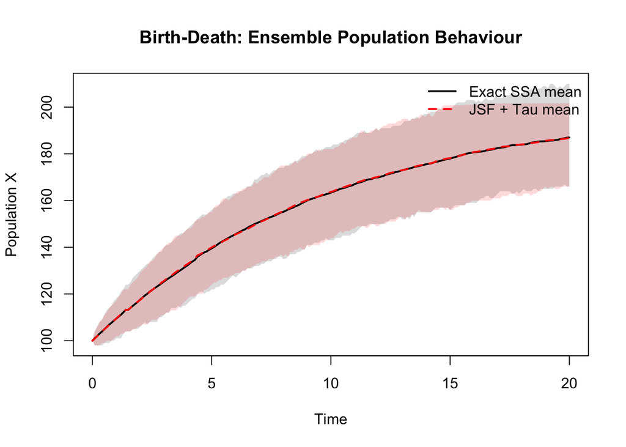

```r
plot_ensemble_comparison(
  grid = bd_grid,
  exact_paths = X_paths_exact_bd,
  hybrid_paths = X_paths_hybrid_bd,
  ylab = "Population X",
  main = "Birth-Death: Ensemble Population Behaviour"
)
```

## Summary Metrics

```r
bd_summary <- data.frame(
  method = c(
    "Exact SSA",
    "JSF + Tau"
  ),
  mean_final_X = c(
    mean(final_X_exact),
    mean(final_X_hybrid)
  ),
  sd_final_X = c(
    sd(final_X_exact),
    sd(final_X_hybrid)
  ),
  mean_path_average_X = c(
    mean(mean_X_exact_path),
    mean(mean_X_hybrid_path)
  ),
  sd_path_average_X = c(
    sd(mean_X_exact_path),
    sd(mean_X_hybrid_path)
  ),
  mean_runtime_seconds = c(
    mean(time_exact_bd),
    mean(time_hybrid_bd)
  )
)

bd_summary
```

```
##      method mean_final_X sd_final_X mean_path_average_X sd_path_average_X
## 1 Exact SSA     186.9960   13.32799            156.9205          7.935710
## 2 JSF + Tau     186.9133   11.87493            157.0435          7.594916
##   mean_runtime_seconds
## 1             0.045574
## 2             0.001180
```

## Error Against Exact SSA

```r
bd_error <- data.frame(
  metric = c(
    "Mean final X error",
    "Relative mean final X error",
    "Mean path-average X error",
    "Relative mean path-average X error",
    "Runtime ratio: hybrid / exact",
    "Speed-up: exact / hybrid"
  ),
  value = c(
    mean(final_X_hybrid) -
      mean(final_X_exact),

    (
      mean(final_X_hybrid) -
        mean(final_X_exact)
    ) /
      mean(final_X_exact),

    mean(mean_X_hybrid_path) -
      mean(mean_X_exact_path),

    (
      mean(mean_X_hybrid_path) -
        mean(mean_X_exact_path)
    ) /
      mean(mean_X_exact_path),

    mean(time_hybrid_bd) /
      mean(time_exact_bd),

    mean(time_exact_bd) /
      mean(time_hybrid_bd)
  )
)

bd_error
```

```
##                               metric         value
## 1                 Mean final X error -0.0827446717
## 2        Relative mean final X error -0.0004424943
## 3          Mean path-average X error  0.1229841715
## 4 Relative mean path-average X error  0.0007837354
## 5      Runtime ratio: hybrid / exact  0.0258919559
## 6           Speed-up: exact / hybrid 38.6220338983
```

## Final-State Distribution

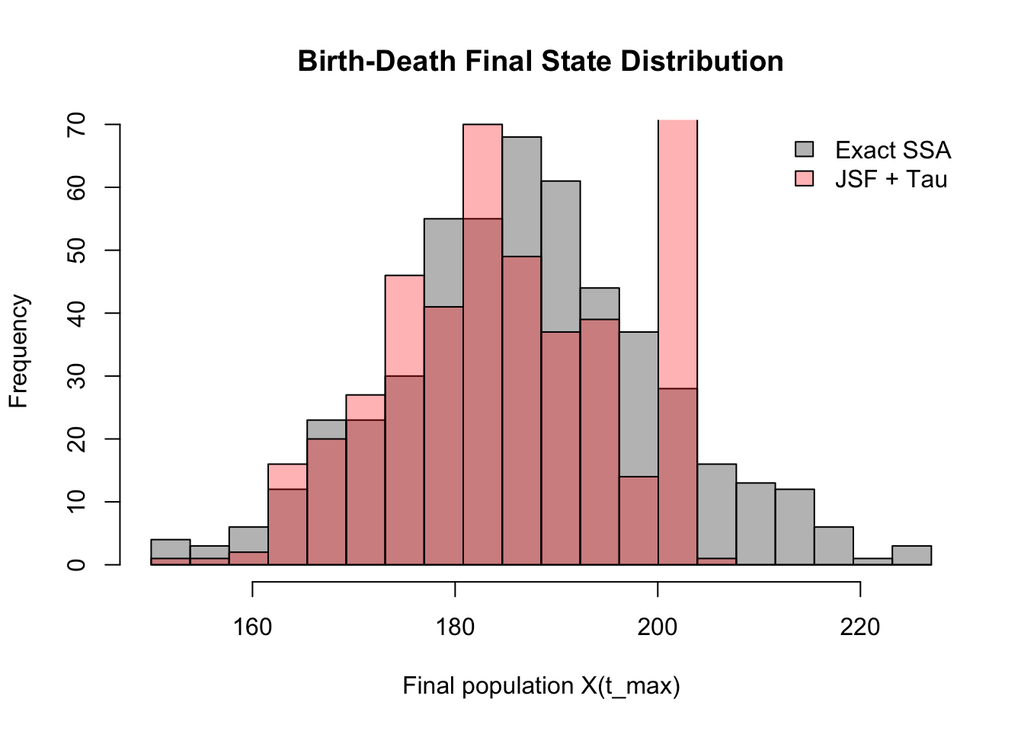

```r
bd_breaks <- common_hist_breaks(
  final_X_exact,
  final_X_hybrid,
  n_bins = 20
)

hist(
  final_X_exact,
  breaks = bd_breaks,
  xlim = range(bd_breaks),
  xlab = "Final population X(t_max)",
  main = "Birth-Death Final State Distribution",
  col = rgb(0, 0, 0, 0.3)
)

hist(
  final_X_hybrid,
  breaks = bd_breaks,
  col = rgb(1, 0, 0, 0.3),
  add = TRUE
)

legend(
  "topright",
  legend = c(
    "Exact SSA",
    "JSF + Tau"
  ),
  fill = c(
    rgb(0, 0, 0, 0.3),
    rgb(1, 0, 0, 0.3)
  ),
  bty = "n"
)
```

## Interpretation

This experiment is a simple sanity check for the Tau-leaping component.

**What works well**

- The ensemble mean trajectory is close to Exact SSA.
- The mean final population is close to Exact SSA.
- The mean path-average population is also close to Exact SSA.
- The final-state distributions can be directly compared using identical histogram bins.
- The runtime improvement is strong.
- This suggests that the Tau-leaping component behaves reasonably in a simple one-species system.

**Overall conclusion**

This is useful as a Tau validation case, but it should not be presented as strong evidence for mixed-regime coupling. It shows that the Tau component can approximate Exact SSA reasonably well in a simple setting while providing faster computation.

# Experiment 3: Weakly Coupled Two-Species Birth-Death Model

## Goal

This experiment tests whether the hybrid method works when two species can evolve in different numerical regimes but are only weakly coupled.

The system has two species:

$$X(t) = (A(t),B(t)).$$

Species $A$ follows a birth-death process.

Species $B$ also follows a birth-death process, but its birth rate depends weakly on $A$.

This introduces coupling without extreme time-scale separation.

## Model

The reactions are:

$$\emptyset \rightarrow A,$$

$$A \rightarrow \emptyset,$$

$$\emptyset \rightarrow B,$$

and

$$B \rightarrow \emptyset.$$

The propensities are:

$$a_1(X)=50,$$

$$a_2(X)=0.1A,$$

$$a_3(X)=10+0.02A,$$

and

$$a_4(X)=0.1B.$$

The weak coupling appears in $a_3(X)$, because the birth propensity of $B$ depends on the current value of $A$.

## Rates and Simulation Parameters

| Quantity | Value | Meaning |
| --- | --- | --- |
| $A$ birth rate | 50 | Constant birth propensity for $A$ |
| $A$ death coefficient | 0.1 | Gives death propensity $0.1A$ |
| $B$ baseline birth rate | 10 | Baseline part of $B$’s birth propensity |
| $A \rightarrow B$ coupling coefficient | 0.02 | Gives coupling term $0.02A$ |
| $B$ death coefficient | 0.1 | Gives death propensity $0.1B$ |
| $A(0)$ | 300 | Initial $A$ population |
| $B(0)$ | 80 | Initial $B$ population |
| $t_{\max}$ | 20 | Simulation horizon |
| Exact SSA `dt` | 0.1 | Output / integration setting |
| Hybrid `dt` | 0.1 | Hybrid time-step setting |
| Hybrid switching threshold | 20 | Jump / Tau / Flow switching threshold |
| Hybrid Tau threshold | 120 | Tau / Flow threshold |

At the initial state $A=300$ and $B=80$, the four propensities are:

$$a_1 = 50,$$

$$a_2 = 0.1(300)=30,$$

$$a_3 = 10+0.02(300)=16,$$

and

$$a_4 = 0.1(80)=8.$$

This makes the numerical scale of each reaction explicit.

## Setup

```r
rates_weak <- reticulate::py_eval(
  "lambda x, t: [50.0, 0.1 * x[0], 10.0 + 0.02 * x[0], 0.1 * x[1]]"
)

reactant_weak <- matrix(c(
  0, 0,
  1, 0,
  0, 0,
  0, 1
), ncol = 2, byrow = TRUE)

product_weak <- matrix(c(
  1, 0,
  0, 0,
  0, 1,
  0, 0
), ncol = 2, byrow = TRUE)
```

## Regime Usage Check

```r
weak_log <- capture.output(
  out_weak_debug <- jsf_simulate(
    x0 = c(A = 300, B = 80),
    rates = rates_weak,
    reactant = reactant_weak,
    product = product_weak,
    do_disc = c(0, 1),
    t_max = 20,
    dt = 0.1,
    switching_threshold = c(20, 20),
    tau_threshold = c(120, 120),
    species_names = c("A", "B"),
    method = "tau-operator-splitting",
    tau_debug = TRUE,
    tau_debug_every = 10,
    tau_debug_max = 80
  )
)

cat(weak_log, sep = "\n")
```

```
## t=0.000, X=[300.0, 80.0], compartmentMode=['flow', 'tau'], reactionMode=['flow', 'flow', 'tau', 'tau']
## t=1.000, X=[319.124, 89.0], compartmentMode=['flow', 'tau'], reactionMode=['flow', 'flow', 'tau', 'tau']
## t=2.000, X=[336.419, 102.0], compartmentMode=['flow', 'tau'], reactionMode=['flow', 'flow', 'tau', 'tau']
## t=3.000, X=[352.06, 99.0], compartmentMode=['flow', 'tau'], reactionMode=['flow', 'flow', 'tau', 'tau']
## t=4.000, X=[366.206, 105.0], compartmentMode=['flow', 'tau'], reactionMode=['flow', 'flow', 'tau', 'tau']
## t=5.000, X=[378.999, 109.0], compartmentMode=['flow', 'tau'], reactionMode=['flow', 'flow', 'tau', 'tau']
## t=6.000, X=[390.569, 110.0], compartmentMode=['flow', 'tau'], reactionMode=['flow', 'flow', 'tau', 'tau']
## t=7.000, X=[401.032, 113.0], compartmentMode=['flow', 'tau'], reactionMode=['flow', 'flow', 'tau', 'tau']
## t=8.000, X=[410.495, 126.421], compartmentMode=['flow', 'flow'], reactionMode=['flow', 'flow', 'flow', 'flow']
## t=9.000, X=[419.054, 131.821], compartmentMode=['flow', 'flow'], reactionMode=['flow', 'flow', 'flow', 'flow']
## t=10.000, X=[426.794, 136.861], compartmentMode=['flow', 'flow'], reactionMode=['flow', 'flow', 'flow', 'flow']
## t=11.000, X=[433.793, 141.561], compartmentMode=['flow', 'flow'], reactionMode=['flow', 'flow', 'flow', 'flow']
## t=12.000, X=[440.124, 145.939], compartmentMode=['flow', 'flow'], reactionMode=['flow', 'flow', 'flow', 'flow']
## t=13.000, X=[445.849, 150.015], compartmentMode=['flow', 'flow'], reactionMode=['flow', 'flow', 'flow', 'flow']
## t=14.000, X=[451.027, 153.805], compartmentMode=['flow', 'flow'], reactionMode=['flow', 'flow', 'flow', 'flow']
## t=15.000, X=[455.71, 157.327], compartmentMode=['flow', 'flow'], reactionMode=['flow', 'flow', 'flow', 'flow']
## t=16.000, X=[459.945, 160.598], compartmentMode=['flow', 'flow'], reactionMode=['flow', 'flow', 'flow', 'flow']
## t=17.000, X=[463.775, 163.634], compartmentMode=['flow', 'flow'], reactionMode=['flow', 'flow', 'flow', 'flow']
## t=18.000, X=[467.238, 166.449], compartmentMode=['flow', 'flow'], reactionMode=['flow', 'flow', 'flow', 'flow']
## t=19.000, X=[470.371, 169.059], compartmentMode=['flow', 'flow'], reactionMode=['flow', 'flow', 'flow', 'flow']
```

```r
weak_regime_usage <- data.frame(
  mode = c(
    "Tau appears",
    "Jump appears",
    "Flow appears"
  ),
  debug_steps = c(
    sum(grepl("reactionMode=.*tau", weak_log)),
    sum(grepl("reactionMode=.*jump", weak_log)),
    sum(grepl("reactionMode=.*flow", weak_log))
  )
)

weak_regime_usage
```

```
##           mode debug_steps
## 1  Tau appears           8
## 2 Jump appears           0
## 3 Flow appears          20
```

## Ensemble Comparison

```r
n_rep <- 500

weak_grid <- seq(
  from = 0,
  to = 20,
  by = 0.1
)

final_A_exact <- numeric(n_rep)
final_B_exact <- numeric(n_rep)

final_A_hybrid <- numeric(n_rep)
final_B_hybrid <- numeric(n_rep)

time_exact_weak <- numeric(n_rep)
time_hybrid_weak <- numeric(n_rep)

A_paths_exact_weak <- matrix(
  NA_real_,
  nrow = n_rep,
  ncol = length(weak_grid)
)

A_paths_hybrid_weak <- matrix(
  NA_real_,
  nrow = n_rep,
  ncol = length(weak_grid)
)

B_paths_exact_weak <- matrix(
  NA_real_,
  nrow = n_rep,
  ncol = length(weak_grid)
)

B_paths_hybrid_weak <- matrix(
  NA_real_,
  nrow = n_rep,
  ncol = length(weak_grid)
)

for (r in seq_len(n_rep)) {

  t_exact <- system.time({
    exact_r <- jsf_simulate(
      x0 = c(A = 300, B = 80),
      rates = rates_weak,
      reactant = reactant_weak,
      product = product_weak,
      do_disc = c(1, 1),
      t_max = 20,
      dt = 0.1,
      switching_threshold = c(1e9, 1e9),
      species_names = c("A", "B"),
      method = "exact"
    )
  })

  t_hybrid <- system.time({
    hybrid_r <- jsf_simulate(
      x0 = c(A = 300, B = 80),
      rates = rates_weak,
      reactant = reactant_weak,
      product = product_weak,
      do_disc = c(0, 1),
      t_max = 20,
      dt = 0.1,
      switching_threshold = c(20, 20),
      tau_threshold = c(120, 120),
      species_names = c("A", "B"),
      method = "tau-operator-splitting"
    )
  })

  final_A_exact[r] <- tail(exact_r$A, 1)
  final_B_exact[r] <- tail(exact_r$B, 1)

  final_A_hybrid[r] <- tail(hybrid_r$A, 1)
  final_B_hybrid[r] <- tail(hybrid_r$B, 1)

  time_exact_weak[r] <- t_exact["elapsed"]
  time_hybrid_weak[r] <- t_hybrid["elapsed"]

  A_paths_exact_weak[r, ] <- path_on_grid(
    exact_r,
    "A",
    weak_grid
  )

  A_paths_hybrid_weak[r, ] <- path_on_grid(
    hybrid_r,
    "A",
    weak_grid
  )

  B_paths_exact_weak[r, ] <- path_on_grid(
    exact_r,
    "B",
    weak_grid
  )

  B_paths_hybrid_weak[r, ] <- path_on_grid(
    hybrid_r,
    "B",
    weak_grid
  )
}
```

## Ensemble Behaviour of Species A

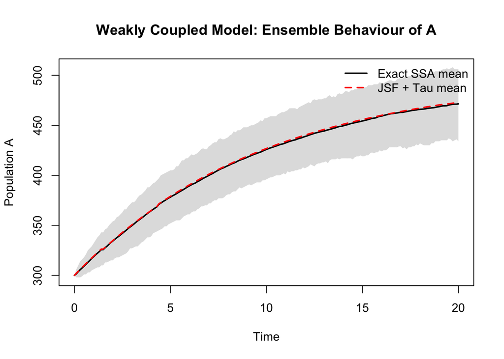

```r
plot_ensemble_comparison(
  grid = weak_grid,
  exact_paths = A_paths_exact_weak,
  hybrid_paths = A_paths_hybrid_weak,
  ylab = "Population A",
  main = "Weakly Coupled Model: Ensemble Behaviour of A"
)
```

## Ensemble Behaviour of Species B

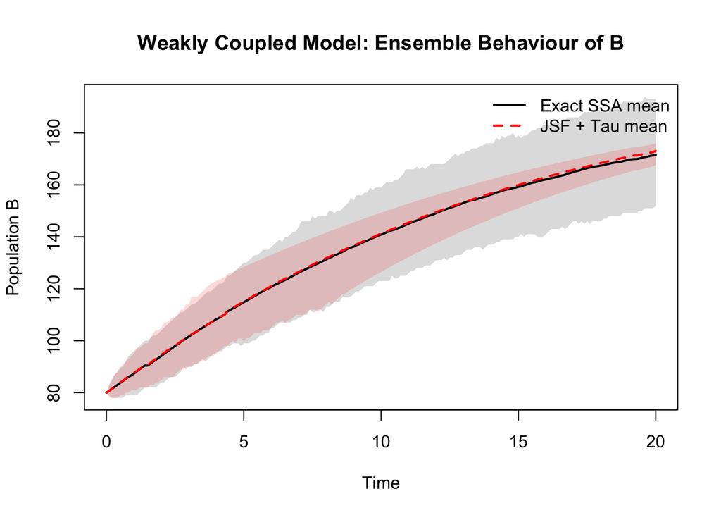

```r
plot_ensemble_comparison(
  grid = weak_grid,
  exact_paths = B_paths_exact_weak,
  hybrid_paths = B_paths_hybrid_weak,
  ylab = "Population B",
  main = "Weakly Coupled Model: Ensemble Behaviour of B"
)
```

## Summary Metrics

```r
weak_summary <- data.frame(
  method = c(
    "Exact SSA",
    "JSF + Tau"
  ),
  mean_final_A = c(
    mean(final_A_exact),
    mean(final_A_hybrid)
  ),
  sd_final_A = c(
    sd(final_A_exact),
    sd(final_A_hybrid)
  ),
  mean_final_B = c(
    mean(final_B_exact),
    mean(final_B_hybrid)
  ),
  sd_final_B = c(
    sd(final_B_exact),
    sd(final_B_hybrid)
  ),
  mean_runtime_seconds = c(
    mean(time_exact_weak),
    mean(time_hybrid_weak)
  )
)

weak_summary
```

```
##      method mean_final_A sd_final_A mean_final_B sd_final_B
## 1 Exact SSA     471.4260   21.81101     171.5760  13.072337
## 2 JSF + Tau     473.2041    0.00000     173.0721   2.541124
##   mean_runtime_seconds
## 1             0.175514
## 2             0.001186
```

## Error Against Exact SSA

```r
weak_error <- data.frame(
  metric = c(
    "Mean final A error",
    "Relative mean final A error",
    "Mean final B error",
    "Relative mean final B error",
    "Runtime ratio: hybrid / exact",
    "Speed-up: exact / hybrid"
  ),
  value = c(
    mean(final_A_hybrid) -
      mean(final_A_exact),

    (
      mean(final_A_hybrid) -
        mean(final_A_exact)
    ) /
      mean(final_A_exact),

    mean(final_B_hybrid) -
      mean(final_B_exact),

    (
      mean(final_B_hybrid) -
        mean(final_B_exact)
    ) /
      mean(final_B_exact),

    mean(time_hybrid_weak) /
      mean(time_exact_weak),

    mean(time_exact_weak) /
      mean(time_hybrid_weak)
  )
)

weak_error
```

```
##                          metric        value
## 1            Mean final A error 1.778065e+00
## 2   Relative mean final A error 3.771674e-03
## 3            Mean final B error 1.496051e+00
## 4   Relative mean final B error 8.719463e-03
## 5 Runtime ratio: hybrid / exact 6.757296e-03
## 6      Speed-up: exact / hybrid 1.479882e+02
```

## Final-State Distribution for A

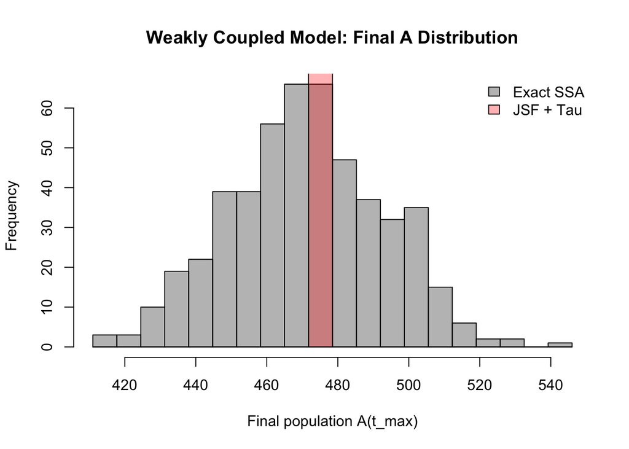

```r
weak_A_breaks <- common_hist_breaks(
  final_A_exact,
  final_A_hybrid,
  n_bins = 20
)

hist(
  final_A_exact,
  breaks = weak_A_breaks,
  xlim = range(weak_A_breaks),
  xlab = "Final population A(t_max)",
  main = "Weakly Coupled Model: Final A Distribution",
  col = rgb(0, 0, 0, 0.3)
)

hist(
  final_A_hybrid,
  breaks = weak_A_breaks,
  col = rgb(1, 0, 0, 0.3),
  add = TRUE
)

legend(
  "topright",
  legend = c(
    "Exact SSA",
    "JSF + Tau"
  ),
  fill = c(
    rgb(0, 0, 0, 0.3),
    rgb(1, 0, 0, 0.3)
  ),
  bty = "n"
)
```

## Final-State Distribution for B

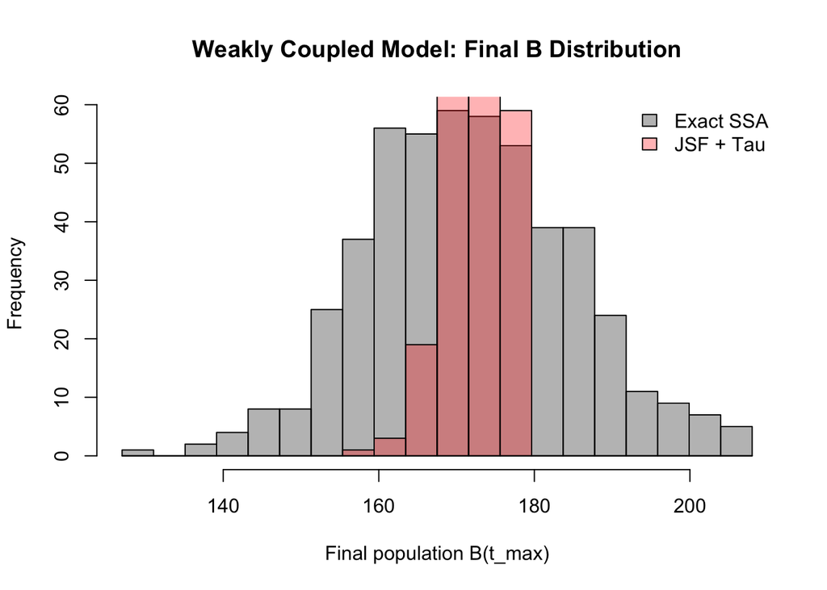

```r
weak_B_breaks <- common_hist_breaks(
  final_B_exact,
  final_B_hybrid,
  n_bins = 20
)

hist(
  final_B_exact,
  breaks = weak_B_breaks,
  xlim = range(weak_B_breaks),
  xlab = "Final population B(t_max)",
  main = "Weakly Coupled Model: Final B Distribution",
  col = rgb(0, 0, 0, 0.3)
)

hist(
  final_B_hybrid,
  breaks = weak_B_breaks,
  col = rgb(1, 0, 0, 0.3),
  add = TRUE
)

legend(
  "topright",
  legend = c(
    "Exact SSA",
    "JSF + Tau"
  ),
  fill = c(
    rgb(0, 0, 0, 0.3),
    rgb(1, 0, 0, 0.3)
  ),
  bty = "n"
)
```

## Interpretation

This experiment is a partial success case.

**What does not work well**

- The hybrid method underestimates stochastic variability.
- Species $A$ is treated mostly as flow, so its dynamics become substantially less stochastic.
- The standard deviation of final $A$ is therefore much smaller under JSF + Tau than under Exact SSA.
- The ensemble envelope for $A$ should consequently be narrower.
- The final distribution of $B$ is also too narrow.
- Because the birth rate of $B$ depends on $A$, reducing the variation in $A$ propagates into the dynamics of $B$.

**Overall conclusion**

This is not a complete failure, but it is also not a complete success. The method is effective for mean behaviour and runtime, but it loses distributional accuracy when an important species is approximated using the Flow regime. This demonstrates a central trade-off in the current prototype: computational speed and mean accuracy can be good even while stochastic variability is underestimated.

# Limitation Case 1: Time-Dependent Birth-Death Process

## Goal

This experiment tests a limitation case in which a propensity changes explicitly over time.

This is important because the current Jump-Tau-Flow implementation evaluates propensities at particular points within its numerical steps.

If the true propensity changes rapidly during a step, a frozen or insufficiently updated propensity can become inaccurate.

## Model

The system has one species $X(t)$ and two reactions:

$$\emptyset \rightarrow X$$

and

$$X \rightarrow \emptyset.$$

The propensities are:

$$a_1(X,t)
=
20 + 15\max(0,\sin(t))$$

and

$$a_2(X,t)
=
0.1X.$$

## Rates and Simulation Parameters

| Quantity | Value | Meaning |
| --- | --- | --- |
| Baseline birth rate | 20 | Minimum birth-rate contribution |
| Time-dependent amplitude | 15 | Maximum additional birth-rate contribution |
| Death coefficient | 0.1 | Gives death propensity $0.1X$ |
| $X(0)$ | 100 | Initial population |
| $t_{\max}$ | 30 | Simulation horizon |
| Exact SSA `dt` | 0.1 | Exact-method setting |
| Hybrid `dt` | 0.1 | Hybrid time-step setting |
| Hybrid switching threshold | 10 | Jump / Tau / Flow switching threshold |
| Hybrid Tau threshold | 200 | Tau / Flow threshold |

The birth propensity therefore satisfies

$$20
\leq
a_{\text{birth}}(t)
\leq
35.$$

Specifically,

$$a_{\text{birth}}(t)
=
20$$

when $\sin(t)\leq0$, while the maximum value is

$$20+15=35.$$

The death propensity is

$$a_{\text{death}}(X)=0.1X.$$

At the initial population $X=100$, the initial death propensity is

$$a_{\text{death}}(100)=10.$$

## Setup

```r
rates_time_bd <- reticulate::py_eval(
  "lambda x, t: [20.0 + 15.0 * max(0.0, __import__('math').sin(t)), 0.1 * x[0]]"
)

reactant_time_bd <- matrix(c(
  0,
  1
), ncol = 1, byrow = TRUE)

product_time_bd <- matrix(c(
  1,
  0
), ncol = 1, byrow = TRUE)
```

## Regime Usage Check

```r
time_bd_log <- capture.output(
  out_time_bd_debug <- jsf_simulate(
    x0 = c(X = 100),
    rates = rates_time_bd,
    reactant = reactant_time_bd,
    product = product_time_bd,
    do_disc = c(1),
    t_max = 30,
    dt = 0.1,
    switching_threshold = c(10),
    tau_threshold = c(200),
    species_names = c("X"),
    method = "tau-operator-splitting",
    tau_debug = TRUE,
    tau_debug_every = 2,
    tau_debug_max = 80
  )
)

cat(time_bd_log, sep = "\n")
```

```
## t=0.000, X=[100.0], compartmentMode=['tau'], reactionMode=['tau', 'tau']
## t=0.200, X=[102.0], compartmentMode=['tau'], reactionMode=['tau', 'tau']
## t=0.400, X=[100.0], compartmentMode=['tau'], reactionMode=['tau', 'tau']
## t=0.600, X=[106.0], compartmentMode=['tau'], reactionMode=['tau', 'tau']
## t=0.800, X=[109.0], compartmentMode=['tau'], reactionMode=['tau', 'tau']
## t=1.000, X=[115.0], compartmentMode=['tau'], reactionMode=['tau', 'tau']
## t=1.200, X=[117.0], compartmentMode=['tau'], reactionMode=['tau', 'tau']
## t=1.400, X=[124.0], compartmentMode=['tau'], reactionMode=['tau', 'tau']
## t=1.600, X=[131.0], compartmentMode=['tau'], reactionMode=['tau', 'tau']
## t=1.800, X=[137.0], compartmentMode=['tau'], reactionMode=['tau', 'tau']
## t=2.000, X=[140.0], compartmentMode=['tau'], reactionMode=['tau', 'tau']
## t=2.200, X=[145.0], compartmentMode=['tau'], reactionMode=['tau', 'tau']
## t=2.400, X=[150.0], compartmentMode=['tau'], reactionMode=['tau', 'tau']
## t=2.600, X=[155.0], compartmentMode=['tau'], reactionMode=['tau', 'tau']
## t=2.800, X=[157.0], compartmentMode=['tau'], reactionMode=['tau', 'tau']
## t=3.000, X=[157.0], compartmentMode=['tau'], reactionMode=['tau', 'tau']
## t=3.200, X=[158.0], compartmentMode=['tau'], reactionMode=['tau', 'tau']
## t=3.400, X=[154.0], compartmentMode=['tau'], reactionMode=['tau', 'tau']
## t=3.600, X=[153.0], compartmentMode=['tau'], reactionMode=['tau', 'tau']
## t=3.800, X=[152.0], compartmentMode=['tau'], reactionMode=['tau', 'tau']
## t=4.000, X=[154.0], compartmentMode=['tau'], reactionMode=['tau', 'tau']
## t=4.200, X=[154.0], compartmentMode=['tau'], reactionMode=['tau', 'tau']
## t=4.400, X=[156.0], compartmentMode=['tau'], reactionMode=['tau', 'tau']
## t=4.600, X=[158.0], compartmentMode=['tau'], reactionMode=['tau', 'tau']
## t=4.800, X=[158.0], compartmentMode=['tau'], reactionMode=['tau', 'tau']
## t=5.000, X=[156.0], compartmentMode=['tau'], reactionMode=['tau', 'tau']
## t=5.200, X=[156.0], compartmentMode=['tau'], reactionMode=['tau', 'tau']
## t=5.400, X=[162.0], compartmentMode=['tau'], reactionMode=['tau', 'tau']
## t=5.600, X=[160.0], compartmentMode=['tau'], reactionMode=['tau', 'tau']
## t=5.800, X=[163.0], compartmentMode=['tau'], reactionMode=['tau', 'tau']
## t=6.000, X=[161.0], compartmentMode=['tau'], reactionMode=['tau', 'tau']
## t=6.200, X=[162.0], compartmentMode=['tau'], reactionMode=['tau', 'tau']
## t=6.400, X=[160.0], compartmentMode=['tau'], reactionMode=['tau', 'tau']
## t=6.600, X=[162.0], compartmentMode=['tau'], reactionMode=['tau', 'tau']
## t=6.800, X=[165.0], compartmentMode=['tau'], reactionMode=['tau', 'tau']
## t=7.000, X=[165.0], compartmentMode=['tau'], reactionMode=['tau', 'tau']
## t=7.200, X=[165.0], compartmentMode=['tau'], reactionMode=['tau', 'tau']
## t=7.400, X=[168.0], compartmentMode=['tau'], reactionMode=['tau', 'tau']
## t=7.600, X=[176.0], compartmentMode=['tau'], reactionMode=['tau', 'tau']
## t=7.800, X=[176.0], compartmentMode=['tau'], reactionMode=['tau', 'tau']
```

[output cut: 25 more lines]

```
## t=13.000, X=[201.898], compartmentMode=['flow'], reactionMode=['flow', 'flow']
## t=13.200, X=[203.247], compartmentMode=['flow'], reactionMode=['flow', 'flow']
## t=13.400, X=[205.066], compartmentMode=['flow'], reactionMode=['flow', 'flow']
## t=13.600, X=[207.27], compartmentMode=['flow'], reactionMode=['flow', 'flow']
## t=13.800, X=[209.76], compartmentMode=['flow'], reactionMode=['flow', 'flow']
## t=14.000, X=[212.425], compartmentMode=['flow'], reactionMode=['flow', 'flow']
## t=14.200, X=[215.148], compartmentMode=['flow'], reactionMode=['flow', 'flow']
## t=14.400, X=[217.809], compartmentMode=['flow'], reactionMode=['flow', 'flow']
## t=14.600, X=[220.291], compartmentMode=['flow'], reactionMode=['flow', 'flow']
## t=14.800, X=[222.485], compartmentMode=['flow'], reactionMode=['flow', 'flow']
## t=15.000, X=[224.292], compartmentMode=['flow'], reactionMode=['flow', 'flow']
## t=15.200, X=[225.631], compartmentMode=['flow'], reactionMode=['flow', 'flow']
## t=15.400, X=[226.438], compartmentMode=['flow'], reactionMode=['flow', 'flow']
## t=15.600, X=[226.672], compartmentMode=['flow'], reactionMode=['flow', 'flow']
## t=15.800, X=[226.313], compartmentMode=['flow'], reactionMode=['flow', 'flow']
```

```r
time_bd_regime_usage <- data.frame(
  mode = c(
    "Tau appears",
    "Jump appears",
    "Flow appears"
  ),
  debug_steps = c(
    sum(grepl("reactionMode=.*tau", time_bd_log)),
    sum(grepl("reactionMode=.*jump", time_bd_log)),
    sum(grepl("reactionMode=.*flow", time_bd_log))
  )
)

time_bd_regime_usage
```

```
##           mode debug_steps
## 1  Tau appears          55
## 2 Jump appears           0
## 3 Flow appears          25
```

## Ensemble Comparison

```r
n_rep <- 500

time_bd_grid <- seq(
  from = 0,
  to = 30,
  by = 0.1
)

final_X_time_exact <- numeric(n_rep)
final_X_time_hybrid <- numeric(n_rep)

mean_X_time_exact_path <- numeric(n_rep)
mean_X_time_hybrid_path <- numeric(n_rep)

time_exact_time_bd <- numeric(n_rep)
time_hybrid_time_bd <- numeric(n_rep)

X_paths_exact_time_bd <- matrix(
  NA_real_,
  nrow = n_rep,
  ncol = length(time_bd_grid)
)

X_paths_hybrid_time_bd <- matrix(
  NA_real_,
  nrow = n_rep,
  ncol = length(time_bd_grid)
)

for (r in seq_len(n_rep)) {

  t_exact <- system.time({
    exact_r <- jsf_simulate(
      x0 = c(X = 100),
      rates = rates_time_bd,
      reactant = reactant_time_bd,
      product = product_time_bd,
      do_disc = c(1),
      t_max = 30,
      dt = 0.1,
      switching_threshold = c(1e9),
      species_names = c("X"),
      method = "exact"
    )
  })

  t_hybrid <- system.time({
    hybrid_r <- jsf_simulate(
      x0 = c(X = 100),
      rates = rates_time_bd,
      reactant = reactant_time_bd,
      product = product_time_bd,
      do_disc = c(1),
      t_max = 30,
      dt = 0.1,
      switching_threshold = c(10),
      tau_threshold = c(200),
      species_names = c("X"),
      method = "tau-operator-splitting"
    )
  })

  final_X_time_exact[r] <- tail(
    exact_r$X,
    1
  )

  final_X_time_hybrid[r] <- tail(
    hybrid_r$X,
    1
  )

  time_exact_time_bd[r] <- t_exact["elapsed"]
  time_hybrid_time_bd[r] <- t_hybrid["elapsed"]

  X_paths_exact_time_bd[r, ] <- path_on_grid(
    exact_r,
    "X",
    time_bd_grid
  )

  X_paths_hybrid_time_bd[r, ] <- path_on_grid(
    hybrid_r,
    "X",
    time_bd_grid
  )

  mean_X_time_exact_path[r] <- mean(
    X_paths_exact_time_bd[r, ]
  )

  mean_X_time_hybrid_path[r] <- mean(
    X_paths_hybrid_time_bd[r, ]
  )
}
```

## Ensemble Population Trajectory

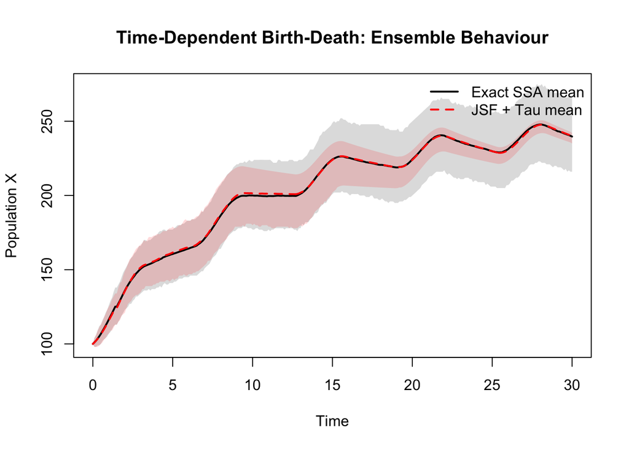

```r
plot_ensemble_comparison(
  grid = time_bd_grid,
  exact_paths = X_paths_exact_time_bd,
  hybrid_paths = X_paths_hybrid_time_bd,
  ylab = "Population X",
  main = "Time-Dependent Birth-Death: Ensemble Behaviour"
)
```

## Summary Metrics

```r
time_bd_summary <- data.frame(
  method = c(
    "Exact SSA",
    "JSF + Tau"
  ),
  mean_final_X = c(
    mean(final_X_time_exact),
    mean(final_X_time_hybrid)
  ),
  sd_final_X = c(
    sd(final_X_time_exact),
    sd(final_X_time_hybrid)
  ),
  mean_path_average_X = c(
    mean(mean_X_time_exact_path),
    mean(mean_X_time_hybrid_path)
  ),
  sd_path_average_X = c(
    sd(mean_X_time_exact_path),
    sd(mean_X_time_hybrid_path)
  ),
  mean_runtime_seconds = c(
    mean(time_exact_time_bd),
    mean(time_hybrid_time_bd)
  )
)

time_bd_summary
```

```
##      method mean_final_X sd_final_X mean_path_average_X sd_path_average_X
## 1 Exact SSA     239.7020  15.958903            203.1849          8.833609
## 2 JSF + Tau     239.6745   2.215526            203.4952          6.372078
##   mean_runtime_seconds
## 1             0.085166
## 2             0.001298
```

## Error Against Exact SSA

```r
time_bd_error <- data.frame(
  metric = c(
    "Mean final X error",
    "Relative mean final X error",
    "Mean path-average X error",
    "Relative mean path-average X error",
    "Runtime ratio: hybrid / exact",
    "Speed-up: exact / hybrid"
  ),
  value = c(
    mean(final_X_time_hybrid) -
      mean(final_X_time_exact),

    (
      mean(final_X_time_hybrid) -
        mean(final_X_time_exact)
    ) /
      mean(final_X_time_exact),

    mean(mean_X_time_hybrid_path) -
      mean(mean_X_time_exact_path),

    (
      mean(mean_X_time_hybrid_path) -
        mean(mean_X_time_exact_path)
    ) /
      mean(mean_X_time_exact_path),

    mean(time_hybrid_time_bd) /
      mean(time_exact_time_bd),

    mean(time_exact_time_bd) /
      mean(time_hybrid_time_bd)
  )
)

time_bd_error
```

```
##                               metric        value
## 1                 Mean final X error -0.027469123
## 2        Relative mean final X error -0.000114597
## 3          Mean path-average X error  0.310365728
## 4 Relative mean path-average X error  0.001527504
## 5      Runtime ratio: hybrid / exact  0.015240824
## 6           Speed-up: exact / hybrid 65.613251156
```

## Final-State Distribution

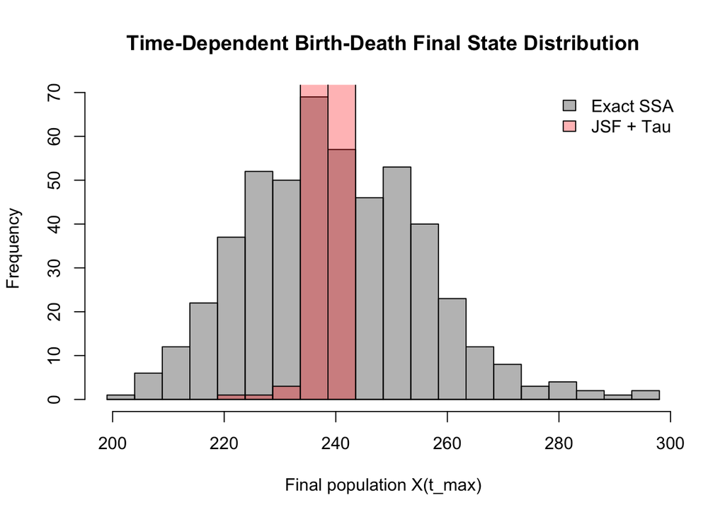

```r
time_bd_breaks <- common_hist_breaks(
  final_X_time_exact,
  final_X_time_hybrid,
  n_bins = 20
)

hist(
  final_X_time_exact,
  breaks = time_bd_breaks,
  xlim = range(time_bd_breaks),
  xlab = "Final population X(t_max)",
  main = "Time-Dependent Birth-Death Final State Distribution",
  col = rgb(0, 0, 0, 0.3)
)

hist(
  final_X_time_hybrid,
  breaks = time_bd_breaks,
  col = rgb(1, 0, 0, 0.3),
  add = TRUE
)

legend(
  "topright",
  legend = c(
    "Exact SSA",
    "JSF + Tau"
  ),
  fill = c(
    rgb(0, 0, 0, 0.3),
    rgb(1, 0, 0, 0.3)
  ),
  bty = "n"
)
```

## Interpretation

This experiment is a limitation case rather than a complete failure.

**What works well**

- The mean final population remains reasonably close to Exact SSA.
- The mean path-average population also remains reasonably close.
- The ensemble mean trajectory captures part of the overall time-dependent behaviour.
- The runtime improvement is substantial.
- This means the hybrid method can still capture aspects of average behaviour even when the birth rate changes over time.

**What does not work well**

- The final-state distribution is substantially narrower under JSF + Tau.
- The method strongly underestimates stochastic variability.
- The standard deviation of the final population is much smaller than under Exact SSA.
- This should also be visible through a narrower ensemble simulation envelope.
- The debug output indicates that the system starts in the Tau regime and later switches into the Flow regime.
- Once the process enters the Flow regime, much of its stochastic variation is removed.

**Why this matters**

- The birth propensity changes explicitly with time between 20 and 35.
- The hybrid method uses a relatively large time step of $dt=0.1$ in this experiment.
- Propensity values may therefore change materially over the duration of an accepted step.
- Even if ensemble means remain reasonably close, the resulting stochastic distribution may be inaccurate.

**Overall conclusion**

This case shows that the method can preserve some aspects of the mean behaviour while failing to preserve the complete stochastic distribution when propensities change over time and the process enters the Flow regime. This is an important limitation of the current implementation.

# Edge Case 2: Catalytic Time-Scale Separation

## Goal

This experiment tests a stronger edge case in which one species evolves slowly and discretely while another species evolves quickly.

This type of time-scale separation is difficult for hybrid coupling.

The concern is that a Jump component may schedule an event using propensity information from one point in time while a Tau or Flow component changes the state substantially before that event occurs.

This can create decoupling between the numerical regimes.

## Model

The system contains two species:

$$C(t),X(t),$$

where $C$ is the slow species and $X$ is the fast species.

The reactions are:

$$C \rightarrow C+X,$$

$$X \rightarrow \emptyset,$$

and

$$X \rightarrow X+C.$$

The corresponding propensities are:

$$a_1(C,X)
=
0.5C,$$

$$a_2(C,X)
=
2X,$$

and

$$a_3(C,X)
=
0.02X.$$

Here $X$ can change quickly because its degradation propensity has coefficient 2.

The slow species $C$ is also affected by $X$, so errors in the fast component can propagate into the slow component.

## Rates and Simulation Parameters

| Quantity | Value | Meaning |
| --- | --- | --- |
| $C \rightarrow C+X$ coefficient | 0.5 | Propensity $0.5C$ |
| $X$ degradation coefficient | 2.0 | Propensity $2X$ |
| $X \rightarrow X+C$ coefficient | 0.02 | Propensity $0.02X$ |
| $C(0)$ | 5 | Initial slow-species population |
| $X(0)$ | 200 | Initial fast-species population |
| $t_{\max}$ | 10 | Simulation horizon |
| Exact SSA `dt` | 0.05 | Exact-method setting |
| Hybrid `dt` | 0.05 | Hybrid time-step setting |
| Hybrid switching threshold | 20 | Jump / Tau / Flow switching threshold |
| Hybrid Tau threshold | 100 | Tau / Flow threshold |

At the initial state

$$C=5,
\qquad
X=200,$$

the reaction propensities are:

$$a_1
=
0.5(5)
=
2.5,$$

$$a_2
=
2(200)
=
400,$$

and

$$a_3
=
0.02(200)
=
4.$$

This explicitly demonstrates the time-scale separation.

The degradation reaction for $X$ initially has propensity 400, compared with propensities 2.5 and 4 for the two other reactions.

Therefore, $X$ can change extremely rapidly early in the simulation.

## Setup

```r
rates_cat <- reticulate::py_eval(
  "lambda x, t: [0.5 * x[0], 2.0 * x[1], 0.02 * x[1]]"
)

reactant_cat <- matrix(c(
  1, 0,
  0, 1,
  0, 1
), ncol = 2, byrow = TRUE)

product_cat <- matrix(c(
  1, 1,
  0, 0,
  1, 1
), ncol = 2, byrow = TRUE)
```

## Regime Usage Check

```r
cat_log <- capture.output(
  out_cat_debug <- jsf_simulate(
    x0 = c(C = 5, X = 200),
    rates = rates_cat,
    reactant = reactant_cat,
    product = product_cat,
    do_disc = c(1, 0),
    t_max = 10,
    dt = 0.05,
    switching_threshold = c(20, 20),
    tau_threshold = c(100, 100),
    species_names = c("C", "X"),
    method = "tau-operator-splitting",
    tau_debug = TRUE,
    tau_debug_every = 1,
    tau_debug_max = 80
  )
)

cat(cat_log, sep = "\n")
```

```
## t=0.000, X=[5.0, 200.0], compartmentMode=['jump', 'flow'], reactionMode=['jump', 'flow', 'jump']
## t=0.050, X=[5.0, 180.0], compartmentMode=['jump', 'flow'], reactionMode=['jump', 'flow', 'jump']
## t=0.100, X=[5.0, 162.0], compartmentMode=['jump', 'flow'], reactionMode=['jump', 'flow', 'jump']
## t=0.150, X=[5.0, 145.8], compartmentMode=['jump', 'flow'], reactionMode=['jump', 'flow', 'jump']
## t=0.200, X=[6.0, 131.22], compartmentMode=['jump', 'flow'], reactionMode=['jump', 'flow', 'jump']
## t=0.250, X=[6.0, 118.098], compartmentMode=['jump', 'flow'], reactionMode=['jump', 'flow', 'jump']
## t=0.300, X=[6.0, 106.288], compartmentMode=['jump', 'flow'], reactionMode=['jump', 'flow', 'jump']
## t=0.350, X=[6.0, 96.659], compartmentMode=['jump', 'flow'], reactionMode=['jump', 'flow', 'jump']
## t=0.400, X=[6.0, 86.993], compartmentMode=['jump', 'flow'], reactionMode=['jump', 'flow', 'jump']
## t=0.450, X=[6.0, 78.294], compartmentMode=['jump', 'flow'], reactionMode=['jump', 'flow', 'jump']
## t=0.500, X=[6.0, 71.465], compartmentMode=['jump', 'flow'], reactionMode=['jump', 'flow', 'jump']
## t=0.550, X=[6.0, 64.318], compartmentMode=['jump', 'flow'], reactionMode=['jump', 'flow', 'jump']
## t=0.600, X=[6.0, 57.886], compartmentMode=['jump', 'flow'], reactionMode=['jump', 'flow', 'jump']
## t=0.650, X=[6.0, 52.098], compartmentMode=['jump', 'flow'], reactionMode=['jump', 'flow', 'jump']
## t=0.700, X=[6.0, 46.888], compartmentMode=['jump', 'flow'], reactionMode=['jump', 'flow', 'jump']
## t=0.750, X=[6.0, 42.199], compartmentMode=['jump', 'flow'], reactionMode=['jump', 'flow', 'jump']
## t=0.800, X=[6.0, 38.979], compartmentMode=['jump', 'flow'], reactionMode=['jump', 'flow', 'jump']
## t=0.850, X=[6.0, 35.081], compartmentMode=['jump', 'flow'], reactionMode=['jump', 'flow', 'jump']
## t=0.900, X=[6.0, 31.573], compartmentMode=['jump', 'flow'], reactionMode=['jump', 'flow', 'jump']
## t=0.950, X=[6.0, 28.416], compartmentMode=['jump', 'flow'], reactionMode=['jump', 'flow', 'jump']
## t=1.000, X=[6.0, 25.574], compartmentMode=['jump', 'flow'], reactionMode=['jump', 'flow', 'jump']
## t=1.050, X=[6.0, 23.017], compartmentMode=['jump', 'flow'], reactionMode=['jump', 'flow', 'jump']
## t=1.100, X=[6.0, 21.715], compartmentMode=['jump', 'flow'], reactionMode=['jump', 'flow', 'jump']
## t=1.150, X=[6.0, 20.544], compartmentMode=['jump', 'flow'], reactionMode=['jump', 'flow', 'jump']
## t=1.200, X=[6.0, 18.489], compartmentMode=['jump', 'flow'], reactionMode=['jump', 'flow', 'jump']
## t=1.250, X=[6.0, 16.64], compartmentMode=['jump', 'flow'], reactionMode=['jump', 'flow', 'jump']
## t=1.300, X=[6.0, 14.976], compartmentMode=['jump', 'flow'], reactionMode=['jump', 'flow', 'jump']
## t=1.350, X=[6.0, 13.479], compartmentMode=['jump', 'flow'], reactionMode=['jump', 'flow', 'jump']
## t=1.400, X=[6.0, 12.131], compartmentMode=['jump', 'flow'], reactionMode=['jump', 'flow', 'jump']
## t=1.450, X=[6.0, 10.918], compartmentMode=['jump', 'flow'], reactionMode=['jump', 'flow', 'jump']
## t=1.500, X=[6.0, 9.826], compartmentMode=['jump', 'flow'], reactionMode=['jump', 'flow', 'jump']
## t=1.550, X=[6.0, 8.843], compartmentMode=['jump', 'flow'], reactionMode=['jump', 'flow', 'jump']
## t=1.600, X=[6.0, 7.959], compartmentMode=['jump', 'flow'], reactionMode=['jump', 'flow', 'jump']
## t=1.650, X=[6.0, 7.163], compartmentMode=['jump', 'flow'], reactionMode=['jump', 'flow', 'jump']
## t=1.700, X=[6.0, 6.447], compartmentMode=['jump', 'flow'], reactionMode=['jump', 'flow', 'jump']
## t=1.750, X=[6.0, 5.802], compartmentMode=['jump', 'flow'], reactionMode=['jump', 'flow', 'jump']
## t=1.800, X=[6.0, 5.222], compartmentMode=['jump', 'flow'], reactionMode=['jump', 'flow', 'jump']
## t=1.850, X=[6.0, 4.7], compartmentMode=['jump', 'flow'], reactionMode=['jump', 'flow', 'jump']
## t=1.900, X=[6.0, 4.23], compartmentMode=['jump', 'flow'], reactionMode=['jump', 'flow', 'jump']
## t=1.950, X=[6.0, 3.807], compartmentMode=['jump', 'flow'], reactionMode=['jump', 'flow', 'jump']
```

[output cut: 25 more lines]

```
## t=3.250, X=[6.0, 2.784], compartmentMode=['jump', 'flow'], reactionMode=['jump', 'flow', 'jump']
## t=3.300, X=[6.0, 2.505], compartmentMode=['jump', 'flow'], reactionMode=['jump', 'flow', 'jump']
## t=3.350, X=[6.0, 2.255], compartmentMode=['jump', 'flow'], reactionMode=['jump', 'flow', 'jump']
## t=3.400, X=[6.0, 2.029], compartmentMode=['jump', 'flow'], reactionMode=['jump', 'flow', 'jump']
## t=3.450, X=[6.0, 1.826], compartmentMode=['jump', 'flow'], reactionMode=['jump', 'flow', 'jump']
## t=3.500, X=[6.0, 1.644], compartmentMode=['jump', 'flow'], reactionMode=['jump', 'flow', 'jump']
## t=3.550, X=[6.0, 1.479], compartmentMode=['jump', 'flow'], reactionMode=['jump', 'flow', 'jump']
## t=3.600, X=[6.0, 1.331], compartmentMode=['jump', 'flow'], reactionMode=['jump', 'flow', 'jump']
## t=3.650, X=[6.0, 1.198], compartmentMode=['jump', 'flow'], reactionMode=['jump', 'flow', 'jump']
## t=3.700, X=[6.0, 1.078], compartmentMode=['jump', 'flow'], reactionMode=['jump', 'flow', 'jump']
## t=3.750, X=[6.0, 1.971], compartmentMode=['jump', 'flow'], reactionMode=['jump', 'flow', 'jump']
## t=3.800, X=[6.0, 2.774], compartmentMode=['jump', 'flow'], reactionMode=['jump', 'flow', 'jump']
## t=3.850, X=[6.0, 2.496], compartmentMode=['jump', 'flow'], reactionMode=['jump', 'flow', 'jump']
## t=3.900, X=[6.0, 2.247], compartmentMode=['jump', 'flow'], reactionMode=['jump', 'flow', 'jump']
## t=3.950, X=[6.0, 2.022], compartmentMode=['jump', 'flow'], reactionMode=['jump', 'flow', 'jump']
```

```r
cat_regime_usage <- data.frame(
  mode = c(
    "Tau appears",
    "Jump appears",
    "Flow appears"
  ),
  debug_steps = c(
    sum(grepl("reactionMode=.*tau", cat_log)),
    sum(grepl("reactionMode=.*jump", cat_log)),
    sum(grepl("reactionMode=.*flow", cat_log))
  )
)

cat_regime_usage
```

```
##           mode debug_steps
## 1  Tau appears           0
## 2 Jump appears          80
## 3 Flow appears          80
```

## Ensemble Comparison

```r
n_rep <- 500

cat_grid <- seq(
  from = 0,
  to = 10,
  by = 0.05
)

final_C_exact <- numeric(n_rep)
final_X_exact <- numeric(n_rep)

final_C_hybrid <- numeric(n_rep)
final_X_hybrid <- numeric(n_rep)

max_C_exact <- numeric(n_rep)
max_C_hybrid <- numeric(n_rep)

time_exact_cat <- numeric(n_rep)
time_hybrid_cat <- numeric(n_rep)

C_paths_exact_cat <- matrix(
  NA_real_,
  nrow = n_rep,
  ncol = length(cat_grid)
)

C_paths_hybrid_cat <- matrix(
  NA_real_,
  nrow = n_rep,
  ncol = length(cat_grid)
)

X_paths_exact_cat <- matrix(
  NA_real_,
  nrow = n_rep,
  ncol = length(cat_grid)
)

X_paths_hybrid_cat <- matrix(
  NA_real_,
  nrow = n_rep,
  ncol = length(cat_grid)
)

for (r in seq_len(n_rep)) {

  t_exact <- system.time({
    exact_r <- jsf_simulate(
      x0 = c(C = 5, X = 200),
      rates = rates_cat,
      reactant = reactant_cat,
      product = product_cat,
      do_disc = c(1, 1),
      t_max = 10,
      dt = 0.05,
      switching_threshold = c(1e9, 1e9),
      species_names = c("C", "X"),
      method = "exact"
    )
  })

  t_hybrid <- system.time({
    hybrid_r <- jsf_simulate(
      x0 = c(C = 5, X = 200),
      rates = rates_cat,
      reactant = reactant_cat,
      product = product_cat,
      do_disc = c(1, 0),
      t_max = 10,
      dt = 0.05,
      switching_threshold = c(20, 20),
      tau_threshold = c(100, 100),
      species_names = c("C", "X"),
      method = "tau-operator-splitting"
    )
  })

  final_C_exact[r] <- tail(exact_r$C, 1)
  final_X_exact[r] <- tail(exact_r$X, 1)

  final_C_hybrid[r] <- tail(hybrid_r$C, 1)
  final_X_hybrid[r] <- tail(hybrid_r$X, 1)

  max_C_exact[r] <- max(exact_r$C)
  max_C_hybrid[r] <- max(hybrid_r$C)

  time_exact_cat[r] <- t_exact["elapsed"]
  time_hybrid_cat[r] <- t_hybrid["elapsed"]

  C_paths_exact_cat[r, ] <- path_on_grid(
    exact_r,
    "C",
    cat_grid
  )

  C_paths_hybrid_cat[r, ] <- path_on_grid(
    hybrid_r,
    "C",
    cat_grid
  )

  X_paths_exact_cat[r, ] <- path_on_grid(
    exact_r,
    "X",
    cat_grid
  )

  X_paths_hybrid_cat[r, ] <- path_on_grid(
    hybrid_r,
    "X",
    cat_grid
  )
}
```

## Ensemble Behaviour of Slow Species C

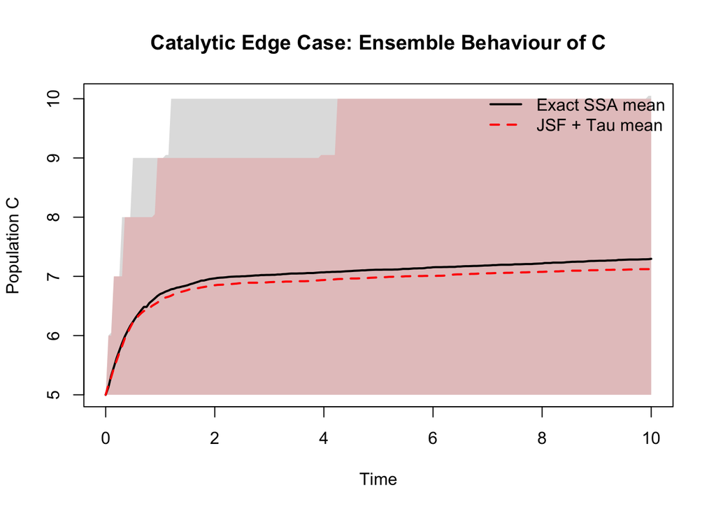

```r
plot_ensemble_comparison(
  grid = cat_grid,
  exact_paths = C_paths_exact_cat,
  hybrid_paths = C_paths_hybrid_cat,
  ylab = "Population C",
  main = "Catalytic Edge Case: Ensemble Behaviour of C"
)
```

## Ensemble Behaviour of Fast Species X

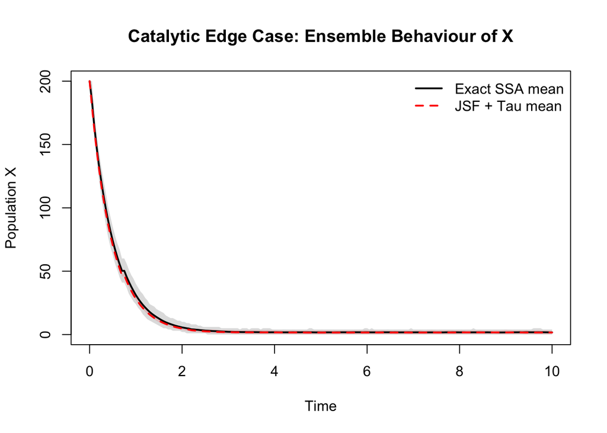

```r
plot_ensemble_comparison(
  grid = cat_grid,
  exact_paths = X_paths_exact_cat,
  hybrid_paths = X_paths_hybrid_cat,
  ylab = "Population X",
  main = "Catalytic Edge Case: Ensemble Behaviour of X"
)
```

## Summary Metrics

```r
cat_summary <- data.frame(
  method = c(
    "Exact SSA",
    "JSF + Tau"
  ),
  mean_final_C = c(
    mean(final_C_exact),
    mean(final_C_hybrid)
  ),
  sd_final_C = c(
    sd(final_C_exact),
    sd(final_C_hybrid)
  ),
  mean_final_X = c(
    mean(final_X_exact),
    mean(final_X_hybrid)
  ),
  sd_final_X = c(
    sd(final_X_exact),
    sd(final_X_hybrid)
  ),
  mean_max_C = c(
    mean(max_C_exact),
    mean(max_C_hybrid)
  ),
  mean_runtime_seconds = c(
    mean(time_exact_cat),
    mean(time_hybrid_cat)
  )
)

cat_summary
```

```
##      method mean_final_C sd_final_C mean_final_X sd_final_X mean_max_C
## 1 Exact SSA        7.296   1.627785     1.704000  1.3446189      7.296
## 2 JSF + Tau        7.124   1.513011     1.581241  0.8563909      7.124
##   mean_runtime_seconds
## 1             0.020510
## 2             0.001404
```

## Error Against Exact SSA

```r
cat_error <- data.frame(
  metric = c(
    "Mean final C error",
    "Relative mean final C error",
    "Mean final X error",
    "Relative mean final X error",
    "Mean max C error",
    "Relative mean max C error",
    "Runtime ratio: hybrid / exact",
    "Speed-up: exact / hybrid"
  ),
  value = c(
    mean(final_C_hybrid) -
      mean(final_C_exact),

    (
      mean(final_C_hybrid) -
        mean(final_C_exact)
    ) /
      mean(final_C_exact),

    mean(final_X_hybrid) -
      mean(final_X_exact),

    (
      mean(final_X_hybrid) -
        mean(final_X_exact)
    ) /
      mean(final_X_exact),

    mean(max_C_hybrid) -
      mean(max_C_exact),

    (
      mean(max_C_hybrid) -
        mean(max_C_exact)
    ) /
      mean(max_C_exact),

    mean(time_hybrid_cat) /
      mean(time_exact_cat),

    mean(time_exact_cat) /
      mean(time_hybrid_cat)
  )
)

cat_error
```

```
##                          metric       value
## 1            Mean final C error -0.17200000
## 2   Relative mean final C error -0.02357456
## 3            Mean final X error -0.12275935
## 4   Relative mean final X error -0.07204187
## 5              Mean max C error -0.17200000
## 6     Relative mean max C error -0.02357456
## 7 Runtime ratio: hybrid / exact  0.06845441
## 8      Speed-up: exact / hybrid 14.60826211
```

## Final C Distribution

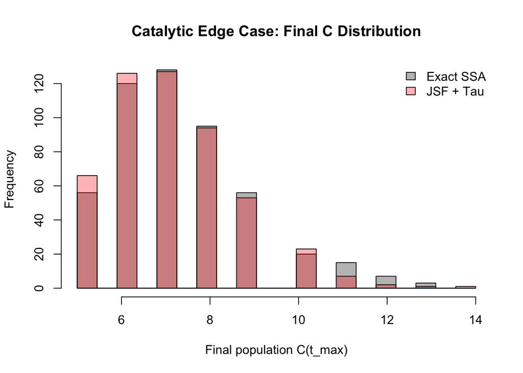

```r
cat_C_breaks <- common_hist_breaks(
  final_C_exact,
  final_C_hybrid,
  n_bins = 20
)

hist(
  final_C_exact,
  breaks = cat_C_breaks,
  xlim = range(cat_C_breaks),
  xlab = "Final population C(t_max)",
  main = "Catalytic Edge Case: Final C Distribution",
  col = rgb(0, 0, 0, 0.3)
)

hist(
  final_C_hybrid,
  breaks = cat_C_breaks,
  col = rgb(1, 0, 0, 0.3),
  add = TRUE
)

legend(
  "topright",
  legend = c(
    "Exact SSA",
    "JSF + Tau"
  ),
  fill = c(
    rgb(0, 0, 0, 0.3),
    rgb(1, 0, 0, 0.3)
  ),
  bty = "n"
)
```

## Interpretation

This experiment is the strongest edge case considered here.

**What works well**

- The hybrid method captures the broad qualitative behaviour of the fast species $X$.
- The ensemble results from both methods show that $X$ decreases rapidly from its large initial population.
- The method remains substantially faster than Exact SSA.

**Why this matters**

At the initial state,

$$a_1 = 2.5,
\qquad
a_2 = 400,
\qquad
a_3 = 4.$$

Therefore, the fast degradation reaction is initially roughly two orders of magnitude faster than the other reactions.

The model consequently contains:

- a slow species $C$,
- a rapidly changing species $X$,
- and a reaction changing $C$ whose propensity depends directly on $X$.

As $X$ changes extremely rapidly, propensity information involving $X$ can become outdated during the hybrid evolution.

This creates a potential decoupling between the slow Jump component and the fast Tau or Flow component.

**Overall conclusion**

# Overall Summary

Across these experiments, the current Jump-Tau-Flow prototype shows a clear trade-off between computational efficiency and preservation of the full stochastic distribution.

## What the Method Does Well

- It can reproduce ensemble means reasonably well in favourable settings.
- It works well on the moderate SIR example.
- It gives reasonable mean accuracy for the simple birth-death process.
- It can handle weak coupling when the primary target is mean behaviour.
- It is substantially faster than Exact SSA across the experiments.
- It can therefore be useful as a fast approximation when exact preservation of stochastic variability is not essential.

## Main Limitations

- The method can underestimate stochastic variability.
- Species treated in the Flow regime can become almost deterministic relative to Exact SSA.
- When another species depends on a Flow-regime species, this reduction in variability can propagate through the system.
- Time-dependent propensities can create difficulties when they change materially during a hybrid step.
- The method is particularly weak when a slow Jump process depends on a rapidly changing Tau or Flow species.

## Importance of Ensemble-Level Evaluation

Because the models are stochastic, comparisons between one Exact SSA trajectory and one JSF + Tau trajectory are not reliable measures of accuracy.

Two correct realizations of the same stochastic model can look substantially different.

Therefore, the experiments here focus on:

- repeated simulations,
- ensemble mean trajectories,
- 5th to 95th percentile simulation envelopes,
- final-state distributions,
- means and standard deviations,
- relative errors,
- and runtime comparisons.

Histograms comparing Exact SSA and JSF + Tau are constructed using the same breaks, which ensures that the bin width and bin boundaries are identical within each comparison.

## Main Failure Mode

The strongest issue appears under time-scale separation.

In particular, difficulties arise when a slow Jump process depends on a fast-changing species.

If the fast species changes substantially while the Jump calculation still depends on earlier propensity information, the numerical regimes can become decoupled.

The consequences can include:

- biased ensemble means,
- overly narrow distributions,
- underestimated stochastic variability,
- or a combination of these effects.

## Final Conclusion

The current Jump-Tau-Flow prototype is promising as a fast hybrid approximation method, particularly for favourable systems where the main goal is to reproduce average behaviour efficiently.

However, it does not always preserve the complete stochastic distribution.

The central limitation identified by these experiments is the coupling between slow Jump dynamics and rapidly changing Tau or Flow dynamics.

The results therefore support the development of a more dynamic coupling mechanism, such as a jump-clock-style update that accounts for changing propensities during each step.

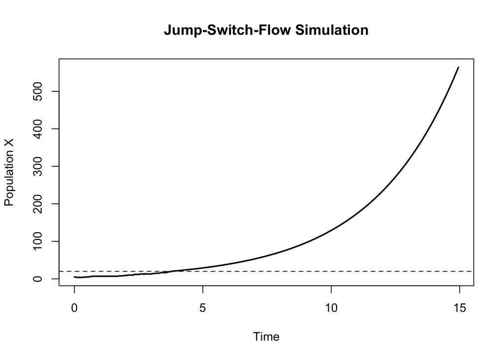

```r
# Growing birth-death process
rates <- reticulate::py_eval(
  "lambda x, t: [0.4 * x[0], 0.1 * x[0]]"
)

reactant <- matrix(c(
  1,   # birth: X -> 2X
  1    # death: X -> 0
), ncol = 1)

product <- matrix(c(
  2,
  0
), ncol = 1)

out <- jsf_simulate(
  x0 = c(X = 5),
  rates = rates,
  reactant = reactant,
  product = product,
  do_disc = c(1),
  t_max = 15,
  dt = 0.05,
  switching_threshold = c(20),
  species_names = "X"
)

plot(
  out$time, out$X,
  type = "l",
  lwd = 2,
  xlab = "Time",
  ylab = "Population X",
  main = "Jump-Switch-Flow Simulation"
)

abline(h = 20, lty = 2)
```